# Topic Modeling with Quanteda

# Packages

```r
# # You may need to install some of these packages - uncomment and run if so
# install.packages("quanteda")
# install.packages("quanteda.textmodels")
# install.packages("devtools") # - for installing packages fromn Github that don't exist on CRAN

# # Topic Modeling
# install.packages("stm") #Structured Topic Models
# #install.packages("seededlda") # Alternative Topic Model implementation: LDA with topic seeding
# #install.packages("topicmodels") # Alternative Topic Model implementation - LDA

# # Visualization and plotting
# install.packages("ggplot2")
# install.packages("wordcloud")
# install.packages("igraph")

#Imports
library("quanteda")
library("quanteda.textmodels")
library("devtools")
#devtools::install_github("quanteda/quanteda.corpora") # Bigger text corpora
library("quanteda.corpora")
library("ggplot2")
library("wordcloud")
library("igraph")
```

# Corpus: Guardian news articles

```r
guardian_corpus <- download("data_corpus_guardian") # This needs quanteda.corpora installed
```

# Preprocessing and Reformatting

- Preprocess the corpus and reformat it as a Document Feature Matrix
- Trim the corpus to weed out less relevant data and make analysis faster

```r
enhanced_stopwords <- c(stopwords("en"), "said", "says", "|") # The pipe and 'says' are very prevalent otherwise
guardian_dfm <- tokens(guardian_corpus, remove_punct = TRUE, remove_numbers = TRUE) %>%
    tokens_remove(enhanced_stopwords) %>%
    # you can stem / lemmatize here if desired
    dfm()

# Trim the corpus: goes from 95k features (99.7% sparse) to 10k features (97.7% sparse)
guardian_dfm <- dfm_trim(guardian_dfm, min_termfreq = 20, min_docfreq = 20)
# Print a summary
guardian_dfm
```

# Try to choose the optimal K (number of topics)

- Uses the STM package; you can choose a different value (below, I use 20), but this tries to optimize for topic coherency
- Warning this has a lot of output and takes a long time! Forgot to time but probably 20+ minutes

```r
# https://www.rdocumentation.org/packages/stm/versions/1.3.6/topics/searchK
out <- convert(guardian_dfm, to='stm')
documents <- out$documents
vocab <- out$vocab
meta <- out$meta
K = c(5,10,15,20,25,30,35,40)
set.seed(42)
kresult <- searchK(documents, vocab, K, data=meta, verbose=FALSE) # meta is only used by STM not LDA. verbose=FALSE?
kresult
```

# Plot the K estimations

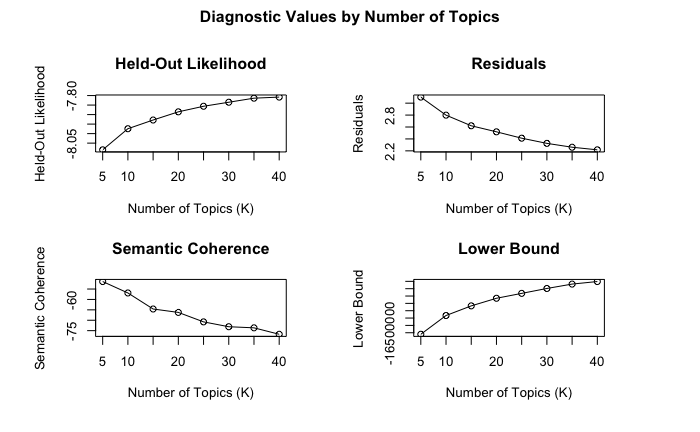

```r
# In depth discussion of model fitting: https://francescocaberlin.blog/2019/06/26/messing-around-with-stm-part-iiia-model-selection/
plot(kresult)
```

# See if we can get a better intersection for various factors

- Warning, runs for a very long time!! About 98 minutes for me
- Semantic coherence bottomed out at 70 topics for me. Running this didn’t make much of a difference
- 40 topics seemed to be ok in terms of “eyeball” coherence, but not much better / more specific than 20

```r
ptm <- proc.time()
k_spread <- c(10, 20, 30, 40, 50, 60, 70, 80, 90, 100)
kresult_big <- searchK(documents, vocab, k_spread, data=meta, verbose=FALSE) # meta is only used by STM not LDA. verbose=FALSE?
print(proc.time() - ptm)
```

```
    user   system  elapsed
5373.022  414.247 5804.780
```

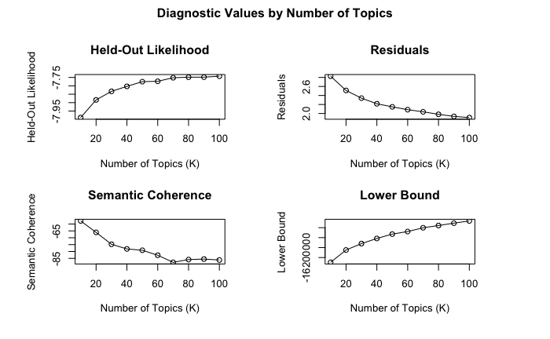

```r
plot(kresult_big)
```

# More plotting

- If you are looking for more options on evaluating models, go check out https://juliasilge.com/blog/evaluating-stm/

# Train our Topic Model!

- We will use the STM (Structured Topic Model) package because it has some nice plotting and summary statistics methods. We already used it above for tuning the K (number of topics) hyperparameter
- See: RDocumentation for STM: https://www.rdocumentation.org/packages/stm/versions/1.3.6
- See: STM vignette: https://cran.r-project.org/web/packages/stm/stm.pdf
- The other implementations above are also good options. STM and `seededlda` have some interesting capabilities that we won’t get into; STM you can provide additional docvar metadata to supposedly improve the modeling. `seededlda` can take “seeded” topics that you as the researcher provide as a starting point for training, almost like creating categories/labels to “center” the topics.

```r
# For k=20, this takes about 2.5 minutes on an M1 Pro with 32GB RAM, 8 minutes on an older Macbook with 16GB RAM
ptm <- proc.time()
guardian_topics_stm <- stm(guardian_dfm, K=20, verbose=FALSE) # verbose=TRUE for feedback while training; K changes the number of topics
proc.time() - ptm
```

# Print the “Top Words” for each topic with different methods for determining relevance

```r
labelTopics(guardian_topics_stm)
```

[output not shown]

# Create a word cloud of a topic’s tokens

```r
cloud(guardian_topics_stm, topic = 13, scale = c(3, 0.25))
```

[output not shown]

# Plot the topics and most strongly associated tokens

```r
# this is STM's default 'plot' rendering, called "summary": # https://www.rdocumentation.org/packages/stm/versions/1.3.6/topics/plot.STM
plot(guardian_topics_stm, n=5) # 5 tokens per topic;
```

[output not shown]

# Yet another way to plot topics, this time with labels which you can generate

```r
## Put labels in a vector; make sure these match up with your topics as they may be different!
labels <- c("Courts / Legal", "Tech", "British Shopping", "Family", "Economy / Markets",
            "British Elections", "Metadata", "Religion / Sexuality", "Climate", "???",
            "Middle East Conflicts", "Healthcare", "US Elections", "NSA / Snowdown", "Local Crime",
            "Banking / Bailout", "Housing", "Air Travel", "Food and Sustainability", "Places and Spaces"
            )
## Extract theta from the stm-model. Theta captures the modal estimate of the proportion of word tokens assigned to the topic under the model (e.g., higher theta = more associated)
df <- data.frame(labels)
proportion <- as.data.frame(colSums(guardian_topics_stm$theta/nrow(guardian_topics_stm$theta)))
df <- cbind(df, proportion)
colnames(df) <- c("Labels", "Probability")

## Sort the dataframe
df <- df[order(-proportion), ]
df$Labels <- factor(df$Labels, levels = rev(df$Labels))
df$Probability <- as.numeric(df$Probability)
df$Probability <- round(df$Probability, 4)

## Plot graph
ggplot(df, aes(x = Labels, y = Probability)) +
  geom_bar(stat = "identity") +
  scale_y_continuous(breaks = c(0, 0.15), limits = c(0, 0.15), expand = c(0, 0)) + #change breaks and limits as you need
  coord_flip() +
  geom_text(aes(label = scales::percent(Probability)), #Scale in percent
            hjust = -0.25, size = 4,
            position = position_dodge(width = 1),
            inherit.aes = TRUE) +
  theme(panel.border = element_blank())
```

[output not shown]

# compare “US politics” and “British politics” topics wtih “perspective” plot type

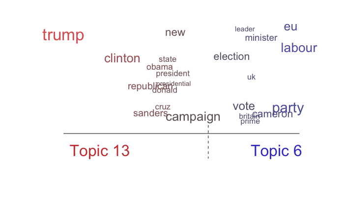

```r
plot(guardian_topics_stm, type = "perspectives", topics = c(13, 6))
```

# Plot topic correlation using igraph

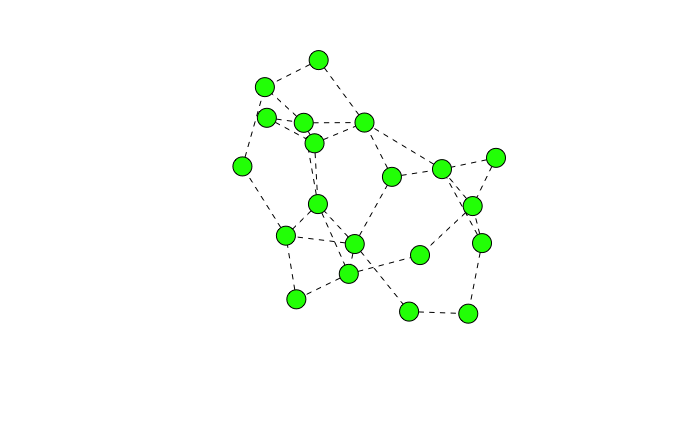

```r
library("igraph")
guardian_topic_correlations <- topicCorr(guardian_topics_stm)
plot(guardian_topic_correlations)
```

# Make a table of topic proportions

```r
guardian_topics_proportions_table <- make.dt(guardian_topics_stm)
summarize_all(guardian_topics_proportions_table, mean)
```

| docnum | Topic1 | Topic2 | Topic3 | Topic4 | Topic5 | Topic6 | Topic7 | Topic8 | Topic9 | Topic10 | Topic11 | Topic12 | Topic13 | Topic14 | Topic15 | Topic16 | Topic17 | Topic18 | Topic19 | Topic20 |
| --- | --- | --- | --- | --- | --- | --- | --- | --- | --- | --- | --- | --- | --- | --- | --- | --- | --- | --- | --- | --- |
| 2998.5 | 0.04206173 | 0.04014619 | 0.05144654 | 0.05539501 | 0.05516212 | 0.07996114 | 0.0191856 | 0.04529228 | 0.03184304 | 0.0852878 | 0.06094554 | 0.04458394 | 0.04097259 | 0.06262847 | 0.0515671 | 0.05567155 | 0.06440237 | 0.02654314 | 0.04387555 | 0.04302831 |

```r
guardian_topics_proportions_table
```

| docnum | Topic1 | Topic2 | Topic3 | Topic4 | Topic5 | Topic6 | Topic7 | Topic8 | Topic9 | Topic10 | Topic11 | Topic12 | Topic13 | Topic14 | Topic15 | Topic16 | Topic17 | Topic18 | Topic19 | Topic20 |
| --- | --- | --- | --- | --- | --- | --- | --- | --- | --- | --- | --- | --- | --- | --- | --- | --- | --- | --- | --- | --- |
| 1 | 7.161403e-03 | 3.350757e-02 | 1.003486e-02 | 7.095971e-03 | 1.911154e-02 | 5.099674e-02 | 8.416540e-03 | 2.004556e-02 | 3.145967e-01 | 0.0850213509 | 1.027413e-02 | 1.733505e-02 | 7.809268e-03 | 1.660244e-01 | 1.189492e-03 | 2.579579e-02 | 4.221977e-02 | 0.0094706611 | 1.489182e-01 | 0.0149750207 |
| 2 | 7.047261e-04 | 2.782912e-01 | 2.312394e-02 | 7.081720e-03 | 3.253045e-03 | 3.496251e-04 | 9.321243e-05 | 1.140851e-03 | 5.079913e-03 | 0.3547205326 | 1.213610e-03 | 7.726515e-03 | 6.141640e-04 | 2.443313e-03 | 2.570697e-03 | 5.270973e-03 | 4.079006e-03 | 0.1278922206 | 4.349792e-02 | 0.1308527821 |
| 3 | 1.685031e-04 | 2.340408e-03 | 2.646255e-03 | 2.023582e-04 | 8.847043e-01 | 5.987551e-03 | 1.558701e-03 | 1.344026e-03 | 4.392579e-02 | 0.0068973857 | 2.151218e-03 | 1.206886e-03 | 7.408639e-04 | 7.106802e-04 | 1.000733e-04 | 2.060270e-02 | 1.149908e-02 | 0.0017266431 | 7.533680e-03 | 0.0039528825 |
| 4 | 5.841993e-02 | 3.126446e-03 | 1.226678e-03 | 5.694428e-03 | 3.829949e-03 | 3.897862e-02 | 2.240239e-01 | 3.314874e-01 | 6.644813e-02 | 0.0124127132 | 5.254865e-03 | 2.201825e-02 | 4.431928e-03 | 5.911930e-02 | 1.774612e-03 | 4.759616e-03 | 1.237844e-01 | 0.0014849716 | 2.212837e-02 | 0.0095955641 |
| 5 | 3.403650e-04 | 5.068673e-05 | 1.935644e-04 | 1.416371e-03 | 1.442094e-03 | 7.147039e-01 | 2.593601e-01 | 3.609500e-03 | 1.118233e-03 | 0.0052749481 | 3.248167e-03 | 2.013355e-04 | 2.920250e-03 | 1.567975e-03 | 4.316755e-04 | 4.028155e-04 | 2.978606e-03 | 0.0003027693 | 1.304761e-04 | 0.0003061718 |
| 6 | 1.040301e-01 | 1.442213e-02 | 1.867862e-02 | 4.158716e-02 | 1.412552e-03 | 3.602550e-03 | 6.608688e-04 | 3.863429e-03 | 5.893069e-04 | 0.1388833168 | 9.021835e-03 | 3.478413e-03 | 3.001262e-03 | 1.475138e-01 | 3.814051e-01 | 8.632093e-02 | 1.797885e-02 | 0.0051748876 | 3.390590e-03 | 0.0149843160 |
| 7 | 3.208812e-04 | 8.537918e-03 | 4.437878e-01 | 3.605376e-03 | 4.751289e-03 | 2.342215e-03 | 3.621472e-05 | 1.038596e-03 | 7.516370e-04 | 0.2084770488 | 1.426169e-04 | 3.612692e-03 | 1.791762e-04 | 3.484202e-03 | 1.336657e-04 | 5.142294e-03 | 1.118619e-01 | 0.0015854078 | 1.957862e-01 | 0.0044229532 |
| 8 | 1.284356e-01 | 1.166548e-02 | 9.580783e-03 | 5.072732e-02 | 2.048109e-03 | 2.727976e-03 | 8.517725e-04 | 3.487429e-03 | 1.931891e-03 | 0.1121255676 | 1.648795e-02 | 3.548516e-03 | 2.367541e-03 | 3.727991e-02 | 2.760859e-01 | 5.138847e-02 | 8.407114e-03 | 0.2384222549 | 2.075636e-03 | 0.0403547640 |
| 9 | 1.486103e-02 | 2.858642e-04 | 5.375179e-04 | 4.109383e-03 | 1.434051e-03 | 1.142953e-01 | 9.910595e-04 | 1.910122e-02 | 3.963070e-03 | 0.0133415901 | 7.991794e-01 | 1.495885e-03 | 1.480135e-03 | 9.730014e-03 | 6.493223e-03 | 1.091096e-03 | 2.862594e-03 | 0.0022059584 | 9.570307e-04 | 0.0015845905 |
| 10 | 1.085585e-03 | 4.279348e-01 | 1.994010e-03 | 8.714641e-04 | 7.167359e-03 | 5.402466e-02 | 9.434305e-04 | 1.592350e-03 | 1.682537e-02 | 0.0368107244 | 6.762678e-04 | 9.679403e-04 | 5.494025e-04 | 5.126177e-02 | 1.165702e-04 | 1.886991e-01 | 1.938314e-01 | 0.0024000250 | 1.169662e-02 | 0.0005511682 |

[output cut: 990 more lines]

What can we do with this table? Find the most associated documents with a topic …

```r
guardian_topics_proportions_table[docnum[order(Topic13, decreasing=TRUE)][1:5]]
```

| docnum | Topic1 | Topic2 | Topic3 | Topic4 | Topic5 | Topic6 | Topic7 | Topic8 | Topic9 | Topic10 | Topic11 | Topic12 | Topic13 | Topic14 | Topic15 | Topic16 | Topic17 | Topic18 | Topic19 | Topic20 |
| --- | --- | --- | --- | --- | --- | --- | --- | --- | --- | --- | --- | --- | --- | --- | --- | --- | --- | --- | --- | --- |
| 3147 | 0.0003512655 | 0.0005462930 | 0.0002443209 | 0.0006135836 | 0.0004302207 | 0.0002585132 | 0.0004150300 | 0.001747180 | 0.0004928955 | 0.003898109 | 0.0004198801 | 0.0002972879 | 0.9878070 | 0.0008140371 | 0.0005057485 | 0.0002423943 | 0.0003555670 | 0.0001436032 | 0.0001834985 | 0.0002335665 |
| 3923 | 0.0003512655 | 0.0005462930 | 0.0002443209 | 0.0006135836 | 0.0004302207 | 0.0002585132 | 0.0004150300 | 0.001747180 | 0.0004928955 | 0.003898109 | 0.0004198801 | 0.0002972879 | 0.9878070 | 0.0008140371 | 0.0005057485 | 0.0002423943 | 0.0003555670 | 0.0001436032 | 0.0001834985 | 0.0002335665 |
| 5964 | 0.0003121448 | 0.0004232390 | 0.0002648213 | 0.0008110471 | 0.0002966508 | 0.0002209994 | 0.0002517402 | 0.001471520 | 0.0005330051 | 0.008111194 | 0.0003891399 | 0.0002617695 | 0.9846489 | 0.0005373428 | 0.0004646461 | 0.0001779112 | 0.0002436181 | 0.0001391769 | 0.0001624191 | 0.0002786917 |
| 4274 | 0.0003334259 | 0.0004104397 | 0.0003493774 | 0.0011283586 | 0.0002258225 | 0.0002659346 | 0.0002964252 | 0.003026231 | 0.0004103036 | 0.007128870 | 0.0005384417 | 0.0002671501 | 0.9833522 | 0.0005646539 | 0.0007283071 | 0.0001267410 | 0.0002128918 | 0.0001435055 | 0.0001617705 | 0.0003291550 |
| 5448 | 0.0003100217 | 0.0004685421 | 0.0002985224 | 0.0008917517 | 0.0003202763 | 0.0002385839 | 0.0002518500 | 0.001495682 | 0.0005627028 | 0.010248398 | 0.0003989914 | 0.0002812352 | 0.9821342 | 0.0005394164 | 0.0004735538 | 0.0001883498 | 0.0002651389 | 0.0001492291 | 0.0001797558 | 0.0003038343 |

```r
docvars(guardian_corpus[3147], field="head") # `head` is a docvar
```

```
[1] "Your cheat sheet for the Arizona and Idaho primaries and Utah caucuses; The results on 22 March could buck the trend of Trump's and Clinton's wins so far in the presidential nomination race - here's a glimpse of how it could play out"
```

```r
print(guardian_corpus[3147], max_nchar=2000)
```

```
Corpus consisting of 1 document and 9 docvars.
text145036 :
"Since 1 February, 62 primary elections have been held to choose the presidential candidates for the next US election - and there are another 47 primaries to go. Here's a quick primer on the next five - two Republican and three Democratic - being held on Tuesday. | In total, 98 Republican and 159 De…
```

# Here’s a different way to find the documents most closely associated with a topic

```r
out <- convert(guardian_dfm, to='stm')
# str(out)
findThoughts(guardian_topics_stm, texts=out$meta$head, n=10, topics=13)$docs[[1]]
```

```
 [1] "Your cheat sheet for the Arizona and Idaho primaries and Utah caucuses; The results on 22 March could buck the trend of Trump's and Clinton's wins so far in the presidential nomination race - here's a glimpse of how it could play out"
 [2] "Your cheat sheet for the Arizona, Idaho and Utah primaries; The results on 22 March could buck the trend of Trump's and Clinton's wins so far in the presidential nomination race - here's a glimpse of how it could play out"
 [3] "Nevada caucus: Donald Trump wins resounding victory over Rubio and Cruz; Exit polls indicate a sweep of virtually every demographic in NevadaRepublican frontrunner extends lead after winning most early voting states"
 [4] "Fight for the right: Cruz and Rubio spar in Nevada to be Trump's challenger; The two Cuban American first-term senators are making contrasting cases to be seen as the alternative to the Republican frontrunner before Tuesday's caucuses"
 [5] "Donald Trump wins Nevada caucuses in resounding victory over Rubio and Cruz; Exit polls indicate a sweep of virtually every demographic in NevadaRepublican frontrunner extends lead after winning most early voting states"
 [6] "Donald Trump wins Nevada caucuses, continuing march to GOP nomination; Businessman has won three of the four early nominating states, accumulating a lead in delegates needed to secure the Republican nomination for president"
 [7] "Trump back on course with big wins in Michigan and Mississippi; Billionaire mogul wins by double digits in both statesTrump victory speech ridicules Republicans who have led attacks on him"
 [8] "Sanders wins West Virginia primary as Trump rolls on toward convention; Sanders' victory does little to narrow Clinton's large delegate lead, while presumptive Republican nominee claims wins in West Virginia and NebraskaWest Virginia and Nebraska primaries: five things we learnedTrump sending …
 [9] "South Carolina governor Nikki Haley to endorse Rubio for president; Haley, who will appear alongside Rubio at an evening campaign event in Chapin, will become the third influential South Carolina official to back Rubio"
[10] "Democratic debate in Flint: what we learned; It was the most aggressive Democratic debate so far, with the candidates sparring over bailouts, Wall Street and trade - and waxing thoughtful on race and religion Full report: Hillary Clinton and Bernie Sanders spar in fierce debate in Flint"
```

# How about finding the topics most associated with an individual document?

```r
# We use the guardian_topics_proportions_table we created above
```

# Fit a new document with an existing model

- See: https://rdrr.io/cran/stm/man/fitNewDocuments.html